# Assignment 1: R and Git Setup

Steve Lamber

`5/26/2026

## Introduction

The purpose of this assignment is to demonstrate that R, RStudio, and GitHub are set up and can be used for basic data analysis. For this assignment, I used the Palmer Penguins dataset. This dataset includes both quantitative variables, such as body mass, bill length, bill depth, and flipper length, and categorical variables, such as species, island, and sex.

The dataset was downloaded from the following web source:

https://raw.githubusercontent.com/allisonhorst/palmerpenguins/main/inst/extdata/penguins.csv

## Import the Dataset

```r
source_url <- "https://raw.githubusercontent.com/allisonhorst/palmerpenguins/main/inst/extdata/penguins.csv"

penguins <- read.csv(source_url)

head(penguins)
```

```
##   species    island bill_length_mm bill_depth_mm flipper_length_mm body_mass_g
## 1  Adelie Torgersen           39.1          18.7               181        3750
## 2  Adelie Torgersen           39.5          17.4               186        3800
## 3  Adelie Torgersen           40.3          18.0               195        3250
## 4  Adelie Torgersen             NA            NA                NA          NA
## 5  Adelie Torgersen           36.7          19.3               193        3450
## 6  Adelie Torgersen           39.3          20.6               190        3650
##      sex year
## 1   male 2007
## 2 female 2007
## 3 female 2007
## 4   <NA> 2007
## 5 female 2007
## 6   male 2007
```

The dataset has been imported into R. The first few rows are displayed above to confirm that the data loaded correctly.

## Review the Structure of the Dataset

```r
str(penguins)
```

```
## 'data.frame':    344 obs. of  8 variables:
##  $ species          : chr  "Adelie" "Adelie" "Adelie" "Adelie" ...
##  $ island           : chr  "Torgersen" "Torgersen" "Torgersen" "Torgersen" ...
##  $ bill_length_mm   : num  39.1 39.5 40.3 NA 36.7 39.3 38.9 39.2 34.1 42 ...
##  $ bill_depth_mm    : num  18.7 17.4 18 NA 19.3 20.6 17.8 19.6 18.1 20.2 ...
##  $ flipper_length_mm: int  181 186 195 NA 193 190 181 195 193 190 ...
##  $ body_mass_g      : int  3750 3800 3250 NA 3450 3650 3625 4675 3475 4250 ...
##  $ sex              : chr  "male" "female" "female" NA ...
##  $ year             : int  2007 2007 2007 2007 2007 2007 2007 2007 2007 2007 ...
```

The structure output shows the variables included in the dataset and their data types. The dataset contains a mix of categorical and quantitative variables, which makes it a useful dataset for practicing basic data analysis in R.

## Descriptive Statistics for Quantitative Variables

```r
quantitative_variables <- penguins[, c("bill_length_mm",
                                       "bill_depth_mm",
                                       "flipper_length_mm",
                                       "body_mass_g")]

summary(quantitative_variables)
```

```
##  bill_length_mm  bill_depth_mm   flipper_length_mm  body_mass_g
##  Min.   :32.10   Min.   :13.10   Min.   :172.0     Min.   :2700
##  1st Qu.:39.23   1st Qu.:15.60   1st Qu.:190.0     1st Qu.:3550
##  Median :44.45   Median :17.30   Median :197.0     Median :4050
##  Mean   :43.92   Mean   :17.15   Mean   :200.9     Mean   :4202
##  3rd Qu.:48.50   3rd Qu.:18.70   3rd Qu.:213.0     3rd Qu.:4750
##  Max.   :59.60   Max.   :21.50   Max.   :231.0     Max.   :6300
##  NAs    :2       NAs    :2       NAs    :2         NAs    :2
```

The summary above provides descriptive statistics for selected quantitative variables. These statistics include the minimum, maximum, mean, median, and quartile values for bill length, bill depth, flipper length, and body mass.

## Descriptive Statistics for Categorical Variables

```r
table(penguins$species)
```

```
##
##    Adelie Chinstrap    Gentoo
##       152        68       124
```

```r
table(penguins$island)
```

```
##
##    Biscoe     Dream Torgersen
##       168       124        52
```

```r
table(penguins$sex, useNA = "ifany")
```

```
##
## female   male   <NA>
##    165    168     11
```

The tables above summarize selected categorical variables. They show how many observations appear in each category for species, island, and sex.

## Transform One Variable

For the transformation step, I converted body mass from grams to kilograms. This creates a new variable called body_mass_kg.

```r
penguins$body_mass_kg <- penguins$body_mass_g / 1000

head(penguins[, c("species", "body_mass_g", "body_mass_kg")])
```

```
##   species body_mass_g body_mass_kg
## 1  Adelie        3750         3.75
## 2  Adelie        3800         3.80
## 3  Adelie        3250         3.25
## 4  Adelie          NA           NA
## 5  Adelie        3450         3.45
## 6  Adelie        3650         3.65
```

This transformation makes body mass easier to interpret because kilograms are a more familiar unit than grams for larger body weight values.

## Plot One Quantitative Variable

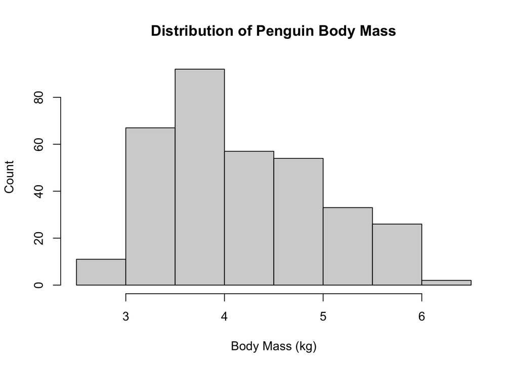

```r
hist(na.omit(penguins$body_mass_kg),
     main = "Distribution of Penguin Body Mass",
     xlab = "Body Mass (kg)",
     ylab = "Count")
```

The histogram above shows the distribution of penguin body mass in kilograms. This helps visualize the spread of body mass values across the observations in the dataset.

## Create a Scatterplot

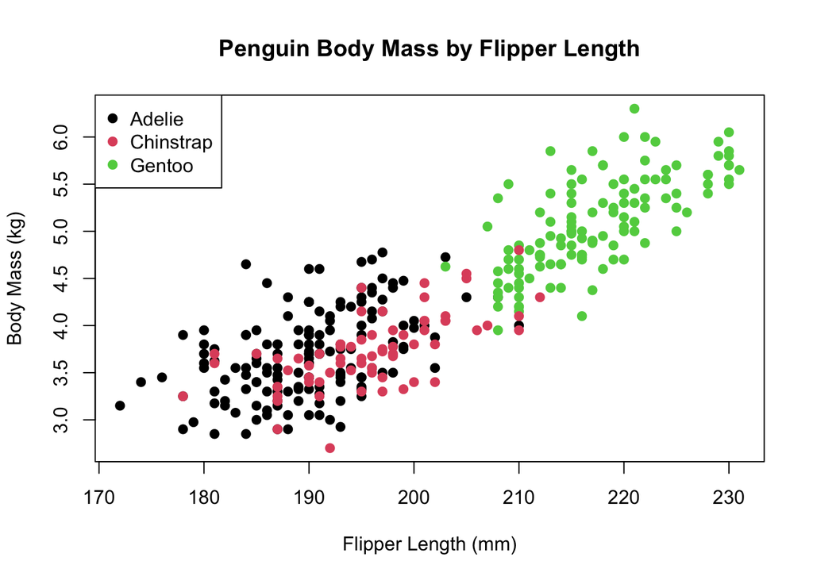

```r
species_factor <- as.factor(penguins$species)
species_colors <- as.numeric(species_factor)

plot(penguins$flipper_length_mm,
     penguins$body_mass_kg,
     main = "Penguin Body Mass by Flipper Length",
     xlab = "Flipper Length (mm)",
     ylab = "Body Mass (kg)",
     col = species_colors,
     pch = 19)

legend("topleft",
       legend = levels(species_factor),
       col = 1:length(levels(species_factor)),
       pch = 19)
```

The scatterplot shows the relationship between flipper length and body mass. In general, penguins with longer flippers appear to have higher body mass. Coloring the points by species also makes it easier to compare the different penguin species.

## Conclusion

This assignment demonstrated how to import a dataset from the web into R, review the structure of the data, calculate descriptive statistics for quantitative and categorical variables, transform a variable, and create basic visualizations. The Palmer Penguins dataset was useful for this assignment because it includes both numeric and categorical data.